# *Revenue prediction*

## a. ANOVA: Income of individuals according to their country

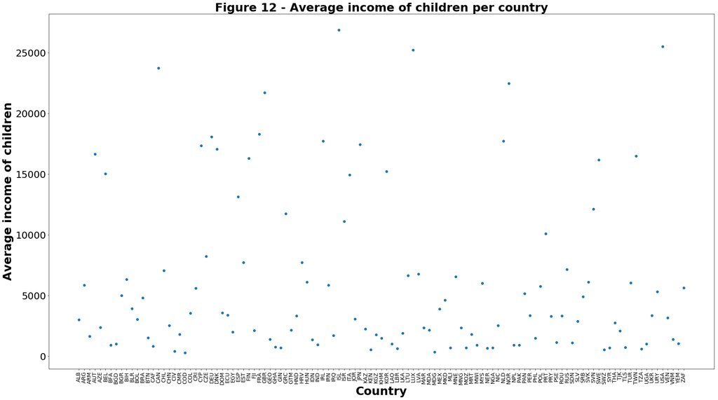

```python
plt.figure(figsize = (31, 17))
plt.plot(final_data.groupby('country').income_child.mean(), 'o')
plt.xlabel('Year',fontsize=30,fontweight = 'bold')
plt.ylabel('Gini Index',fontsize=30,fontweight = 'bold')
plt.xticks(rotation=90)
plt.yticks(fontsize=25)
plt.xlabel('Country')
plt.ylabel('Average income of children')
plt.title('Figure 12 - Average income of children per country',fontsize=30,fontweight = 'bold')
plt.savefig('figure/Figure 12 - Average income of children per country.png', dpi=300)
plt.show()
```

### ANOVA

The country seems to have an impact on the average income of the child. ANOVA allows us to confirm or refute this intuition.

Hypothesis H0: The country has no impact on the average income of the child.

Hypothesis H1: The country has an impact on the average income of the child.

Threshold of significance: α = 5%

Statistic F: F = f (Variance Inter / Variance Intra): Follows a law of Fischer

```python
anova1 = smf.ols('income_child~country', data=final_data_sampled).fit()
print(anova1.summary())
```

```
                            OLS Regression Results
==============================================================================
Dep. Variable:           income_child   R-squared:                       0.496
Model:                            OLS   Adj. R-squared:                  0.496
Method:                 Least Squares   F-statistic:                     9910.
Date:                Mon, 28 Oct 2019   Prob (F-statistic):               0.00
Time:                        12:17:59   Log-Likelihood:            -1.1766e+07
No. Observations:             1150000   AIC:                         2.353e+07
Df Residuals:                 1149885   BIC:                         2.353e+07
Df Model:                         114
Covariance Type:            nonrobust
==================================================================================
                     coef    std err          t      P>|t|      [0.025      0.975]
----------------------------------------------------------------------------------
Intercept       3006.0288     67.196     44.736      0.000    2874.328    3137.730
country[T.ARG]  2881.6667     95.029     30.324      0.000    2695.413    3067.920
country[T.ARM] -1369.5005     95.029    -14.411      0.000   -1555.754   -1183.247
country[T.AUT]  1.365e+04     95.029    143.632      0.000    1.35e+04    1.38e+04
country[T.AZE]  -651.3205     95.029     -6.854      0.000    -837.574    -465.067
country[T.BEL]  1.212e+04     95.029    127.489      0.000    1.19e+04    1.23e+04
country[T.BFA] -2079.3239     95.029    -21.881      0.000   -2265.577   -1893.071
country[T.BGD] -2013.3496     95.029    -21.187      0.000   -2199.603   -1827.096
country[T.BGR]  2032.9669     95.029     21.393      0.000    1846.714    2219.220
country[T.BIH]  3400.8381     95.029     35.787      0.000    3214.585    3587.091
country[T.BLR]   900.3081     95.029      9.474      0.000     714.055    1086.561
country[T.BOL]     3.7341     95.029      0.039      0.969    -182.519     189.987
country[T.BRA]  1775.4882     95.029     18.684      0.000    1589.235    1961.741
country[T.BTN] -1484.6507     95.029    -15.623      0.000   -1670.904   -1298.397
country[T.CAF] -2192.6759     95.029    -23.074      0.000   -2378.929   -2006.423
country[T.CAN]  2.061e+04     95.029    216.832      0.000    2.04e+04    2.08e+04
country[T.CHL]  4026.1298     95.029     42.367      0.000    3839.877    4212.383
country[T.CHN]  -512.7170     95.029     -5.395      0.000    -698.970    -326.464
country[T.CIV] -2609.5986     95.029    -27.461      0.000   -2795.852   -2423.345
country[T.CMR] -1186.8895     95.029    -12.490      0.000   -1373.143   -1000.636
country[T.COD] -2729.5627     95.029    -28.724      0.000   -2915.816   -2543.309
country[T.COL]   523.5348     95.029      5.509      0.000     337.282     709.788
country[T.CRI]  2614.2189     95.029     27.510      0.000    2427.966    2800.472
country[T.CYP]  1.425e+04     95.029    150.005      0.000    1.41e+04    1.44e+04
country[T.CZE]  5242.8399     95.029     55.171      0.000    5056.587    5429.093
country[T.DEU]  1.515e+04     95.029    159.414      0.000     1.5e+04    1.53e+04
```

[output cut: 83 more lines]

```
country[T.URY]  2233.8490     95.029     23.507      0.000    2047.596    2420.102
country[T.USA]  2.262e+04     95.029    238.026      0.000    2.24e+04    2.28e+04
country[T.VEN]   151.7444     95.029      1.597      0.110     -34.509     337.998
country[T.VNM] -1637.9547     95.029    -17.236      0.000   -1824.208   -1451.701
country[T.YEM] -1966.5023     95.029    -20.694      0.000   -2152.755   -1780.249
country[T.ZAF]  2598.3498     95.029     27.343      0.000    2412.097    2784.603
==============================================================================
Omnibus:                  1440370.572   Durbin-Watson:                   2.007
Prob(Omnibus):                  0.000   Jarque-Bera (JB):        402078361.781
Skew:                           6.690   Prob(JB):                         0.00
Kurtosis:                      93.621   Cond. No.                         116.
==============================================================================

Warnings:
[1] Standard Errors assume that the covariance matrix of the errors is correctly specified.
```

### Analysis : ANOVA results

```python
sm.stats.anova_lm(anova1, typ=2)
```

|  | sum_sq | df | F | PR(>F) |
| --- | --- | --- | --- | --- |
| country | 5.100912e+13 | 114.0 | 9909.742428 | 0.0 |
| Residual | 5.192004e+13 | 1149885.0 | NaN | NaN |

$ eta ^ {2} $: 0.50: The country explains 50% of the child's income variability.

P-value: < 5%: Hypothesis H0 is rejected.

The country has an impact on the average income of the child.

### Verification of test validity hypotheses

### Assessment of independence

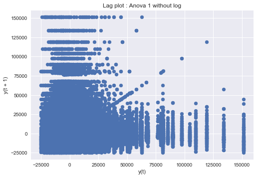

```python
import seaborn as sns
from pandas.plotting import lag_plot
plt.style.use('seaborn') # pretty matplotlib plots

# Residue independence hypothesis
plt.title('Lag plot : Anova 1 without log')
lag_plot(anova1.resid)
plt.savefig('figure/Figure - Lag plot :  Anova 1 without log.png', dpi=300)
```

```python
from statsmodels.stats.stattools import durbin_watson
durbin_watson(anova1.resid)
```

```
2.0074875282331304
```

The lag plot does not show a structured form. The residues seem independent. This is confirmed by the Durbin-Watson test whose statistic is close to 2.

### Evaluation of the hypothesis of normality of residues

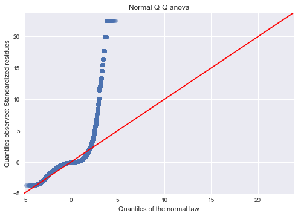

```python
plot_qq_plot(anova1,'anova')
```

```python
test_shapiro(anova1)
```

```
Statistics=0.563, p=0.000
Sample does not look Gaussian (reject H0)
```

The QQ comparison diagram of a normalized observed distribution with a reduced Gaussian law allows a subjective validation: if the points are aligned with the first bisector, it is because the distribution probably follows a standardized Gaussian distribution law: it is not the case here. In addition, the p-value of the Shapiro test leads us to reject the hypothesis H0, hypothesis of normality of the residues.

### Evaluation of the homogeneity hypothesis of residues

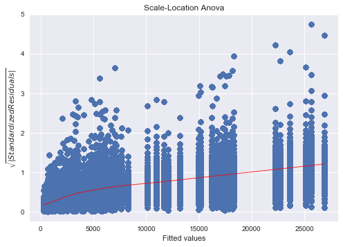

```python
plot_scale_location(anova1,'Anova')
```

```python
# Test :  homogeneity hypothesis of residues
country_levene = []
for code in final_data_sampled['country'].drop_duplicates():
    country_levene.append(final_data_sampled[final_data_sampled['country']==code]['income_child'])
st.levene(*country_levene)
```

```
LeveneResult(statistic=2534.7406252900087, pvalue=0.0)
```

The p-value is less than 5%. The hypothesis of homogeneity of the residues is refused: the variances are not equal.

### Non parametric ANOVA

In this situation of rejection of the assumptions of normality and homogeneity of the residues, it is possible to compare the means using a nonparametric ANOVA, or Kruskal-Wallis test.

```python
country_kruskal = []
for code in final_data_sampled['country'].drop_duplicates():
    country_kruskal.append(final_data_sampled[final_data_sampled['country']==code]['income_child'])
st.kruskal(*country_kruskal)
```

```
KruskalResult(statistic=853744.3269865265, pvalue=0.0)
```

As the test value is less than 0.05, the assumption of equality of averages is rejected. It is therefore concluded that the average income of children in countries is different.

## b. Linear Regression 1: Income of Individuals by Country Average Income and Gini Index

A linear regression is applied to the data, including as explanatory variables only the average income of the country of the individual and the Gini index of the country of the individual.

### Without logarithm

#### Linear Regression

```python
regr1 = smf.ols('income_child~gdpppp+indice_gini', data=final_data_sampled).fit()
```

#### Checking the validity assumptions of the F test

#### Assessment of independence

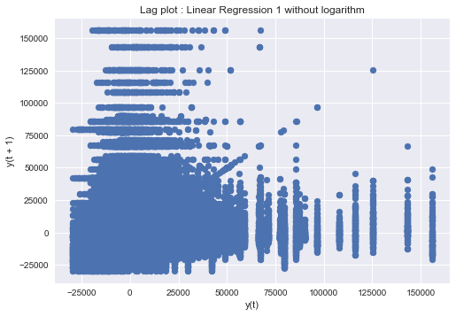

```python
plt.title('Lag plot : Linear Regression 1 without logarithm')
lag_plot(regr1.resid)
plt.savefig('figure/Figure - Linear Regression 1 without logarithm.png', dpi=300)
```

```python
durbin_watson(regr1.resid)
```

```
1.8304792875917573
```

The lag plot does not show a structured form. The residues seem independent. This is confirmed by the Durbin-Watson test whose statistic is close to 2.

#### Evaluation of the hypothesis of normality of residues

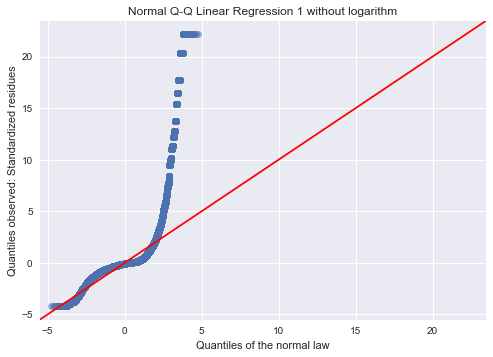

```python
plot_qq_plot(regr1,'Linear Regression 1 without logarithm')
```

```python
test_shapiro(regr1)
```

```
Statistics=0.577, p=0.000
Sample does not look Gaussian (reject H0)
```

The QQ comparison diagram of a normalized observed distribution with a reduced Gaussian law allows a subjective validation: if the points are aligned with the first bisector, it is because the distribution probably follows a standardized Gaussian distribution law: it is not the case here. In addition, the p-value of the Shapiro test leads us to reject the hypothesis H0, hypothesis of normality of the residues.

#### Evaluation of the homogeneity hypothesis of residues

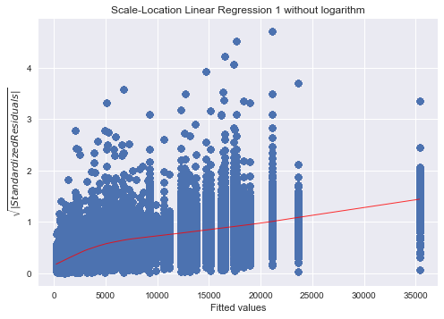

```python
plot_scale_location(regr1,'Linear Regression 1 without logarithm')
```

```python
test_breuschpagan(regr1)
```

```
Statistics=14900.772, p=0.000
Residue homogeneity assumption is rejected.
```

The more the red line is horizontal, the more homogeneous the residue hypothesis is valid. Here, the variance of the residues is not constant. In fact, the higher the values taken by the model, the more the residues have a high value. In addition, the Breusch-Pagan test rejects the hypothesis of homogeneity of residues.

Since the normality hypothesis and the residue homoskedasticity hypothesis are not valid, a logarithm is applied to the children's incomes, and for the average income per country.

### With logarithm

#### Linear Regression

```python
regr1_log = smf.ols('income_child~gdpppp+indice_gini', data=final_data_sampled_log).fit()
```

#### Checking the validity assumptions of the F test

#### Assessment of independence

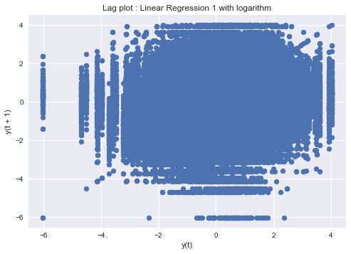

```python
plt.title('Lag plot : Linear Regression 1 with logarithm')
lag_plot(regr1_log.resid)
plt.savefig('figure/Figure - Lag plot : Linear Regression 1 with logarithm.png', dpi=300)
```

```python
durbin_watson(regr1_log.resid)
```

```
1.57349405873944
```

The lag plot does not show a structured form. The residues seem independent. This is confirmed by the Durbin-Watson test whose statistic is close to 2.

#### Evaluation of the hypothesis of normality of residues

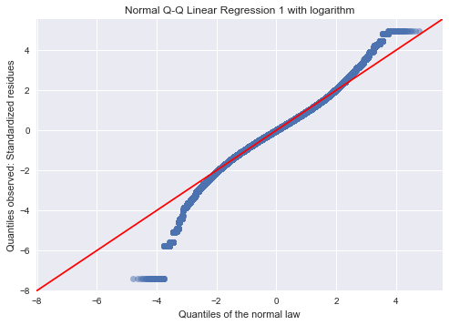

```python
plot_qq_plot(regr1_log,'Linear Regression 1 with logarithm')
```

```python
test_shapiro(regr1_log)
```

```
Statistics=0.990, p=0.000
Sample does not look Gaussian (reject H0)
```

In comparison with the non-logarithmic case, the points are better aligned with the first bisector: the distribution follows approximately a Gaussian normalized distribution law. The hypothesis of normality of the residues seems verified. However, the Shapiro-Wilk test tells us the opposite and rejects the hypothesis H0, hypothesis of normality of residues: this may be due to influential outliers / points or because the number of data studied is very large.

### Evaluation of the homogeneity hypothesis of residues

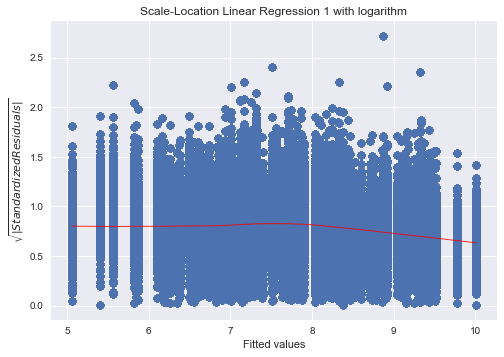

```python
plot_scale_location(regr1_log,'Linear Regression 1 with logarithm')
```

```python
test_breuschpagan(regr1_log)
```

```
Statistics=14900.772, p=0.000
Residue homogeneity assumption is rejected.
```

In comparison with the non-logarithmic case, the variance of the residues seems constant. ** The hypothesis of homogeneity of residues seems to be verified **. However, the Breusch-Pagan test tells us the opposite and rejects the hypothesis H0, hypothesis of homogeneity of the residues: this can be due to influential outliers / points or because the number of data studied is very large.

#### Linear Regression : Results

```python
print(regr1_log.summary())
```

```
                            OLS Regression Results
==============================================================================
Dep. Variable:           income_child   R-squared:                       0.657
Model:                            OLS   Adj. R-squared:                  0.657
Method:                 Least Squares   F-statistic:                 1.099e+06
Date:                Mon, 28 Oct 2019   Prob (F-statistic):               0.00
Time:                        12:24:01   Log-Likelihood:            -1.3927e+06
No. Observations:             1150000   AIC:                         2.785e+06
Df Residuals:                 1149997   BIC:                         2.785e+06
Df Model:                           2
Covariance Type:            nonrobust
===============================================================================
                  coef    std err          t      P>|t|      [0.025      0.975]
-------------------------------------------------------------------------------
Intercept       1.0156      0.008    134.760      0.000       1.001       1.030
gdpppp          0.8577      0.001   1353.697      0.000       0.856       0.859
indice_gini    -0.0187   9.65e-05   -193.867      0.000      -0.019      -0.019
==============================================================================
Omnibus:                    39416.238   Durbin-Watson:                   1.573
Prob(Omnibus):                  0.000   Jarque-Bera (JB):           109135.111
Skew:                          -0.093   Prob(JB):                         0.00
Kurtosis:                       4.498   Cond. No.                         398.
==============================================================================

Warnings:
[1] Standard Errors assume that the covariance matrix of the errors is correctly specified.
```

#### Checking collinearity of variables

In a regression, multicollinearity is a problem that occurs when some predictor variables in the model measure the same phenomenon. High multicollinearity is problematic because it can increase the variance of the regression coefficients and make them unstable and difficult to interpret.

```python
test_colinearite(regr1_log)
```

```
[1.0883554485525595, 1.0883554485526012]
```

The VIF coefficients of our variables are < 10: there is no collinearity problem.

#### Distance from Cook: Influent Outliers

```python
pourcentage_outliers_influents(final_data_sampled_log, regr1_log)
```

```
5.58 % of individuals are influential outliers
```

These points influence the regression. However, they are preserved because they are supposed to represent real individuals.

#### Results analysis

Prob (F-statistic) < 5%: The model is significant.

P-values: index_gini, gdpppp: < 5%: The coefficients are significant with a 95% confidence interval.

```python
res_regr1_log = sm.stats.anova_lm(regr1_log, typ=2)
res_regr1_log
```

|  | sum_sq | df | F | PR(>F) |
| --- | --- | --- | --- | --- |
| gdpppp | 1.209052e+06 | 1.0 | 1.832494e+06 | 0.0 |
| indice_gini | 2.479762e+04 | 1.0 | 3.758440e+04 | 0.0 |
| Residual | 7.587505e+05 | 1149997.0 | NaN | NaN |

```python
regr1_log_sct = res_regr1_log.values[:,0].sum()
regr1_log_sce = res_regr1_log.values[0,0]+res_regr1_log.values[1,0]
regr1_log_scr = res_regr1_log.values[2,0]
regr1_log_sce_gdpppp = sm.stats.anova_lm(regr1_log, typ=2).values[0,0]/regr1_log_sct
regr1_log_sce_indice_gini = sm.stats.anova_lm(regr1_log, typ=2).values[1,0]/regr1_log_sct
regr1_log_r2 = regr1_log_sce/regr1_log_sct

print("        SCT = ", round(regr1_log_sct))
print("        SCE = ", round(regr1_log_sce))
print("        SCR = ", round(regr1_log_scr))
print("Variance explained by the country's average income (gdpppp ) =",round(100*regr1_log_sce_gdpppp,2),'%')
print("                        Variance explained by the gini index = ",round(100*regr1_log_sce_indice_gini,2),'%')
print("                  Variance explained by the R2-squared model =", round(100*regr1_log_r2),"%")
print("                           Variance unexplained by the model =", round(100*regr1_log_scr/regr1_log_sct),"%")
print("Conclusion : The model ln(gdpppp) + indice_gini explain", round(100*regr1_log_r2),"% of the total variance of ln(income_enfant).")
```

```
        SCT =  1992600.0
        SCE =  1233850.0
        SCR =  758750.0
Variance explained by the country's average income (gdpppp ) = 60.68 %
                        Variance explained by the gini index =  1.24 %
                  Variance explained by the R2-squared model = 62.0 %
                           Variance unexplained by the model = 38.0 %
Conclusion : The model ln(gdpppp) + indice_gini explain 62.0 % of the total variance of ln(income_enfant).
```

## c. Income of individuals according to the average income of the country, the country's Gini index and the parents' income class

This time, the parents' income class is introduced in addition to the model.

### Without logarithm

#### Linear Regression

```python
regr2 = smf.ols('income_child~gdpppp+indice_gini+c_k_parent', data=final_data_sampled).fit()
```

#### Checking the validity assumptions of the F test

#### Assessment of independence

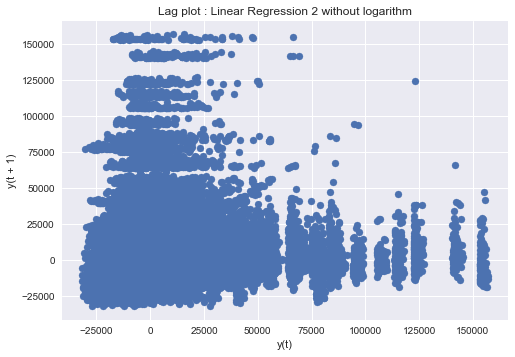

```python
plt.title('Lag plot : Linear Regression 2 without logarithm')
lag_plot(regr2.resid)
plt.savefig('figure/Figure - Lag plot : Linear Regression 2 without logarithm.png', dpi=300)
```

```python
durbin_watson(regr2.resid)
```

```
1.8231627374820998
```

The lag plot does not show a structured form. The residues seem independent. This is confirmed by the Durbin-Watson test whose statistic is close to 2.

#### Evaluation of the hypothesis of normality of residues

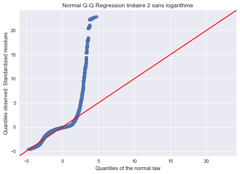

```python
plot_qq_plot(regr2,'Regression linéaire 2 sans logarithme')
```

```python
test_shapiro(regr2)
```

```
Statistics=0.585, p=0.000
Sample does not look Gaussian (reject H0)
```

The QQ comparison diagram of a normalized observed distribution with a reduced Gaussian law allows a subjective validation: if the points are aligned with the first bisector, it is because the distribution probably follows a standardized Gaussian distribution law: it is not the case here. In addition, the p-value of the Shapiro test leads us to reject the hypothesis H0, hypothesis of normality of the residues.

#### Evaluation of the homogeneity hypothesis of residues

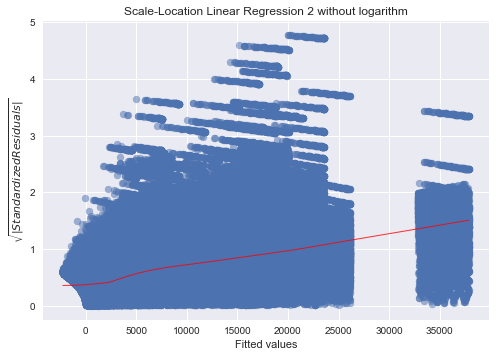

```python
plot_scale_location(regr2,'Linear Regression 2 without logarithm')
```

```python
test_breuschpagan(regr2)
```

```
Statistics=14900.772, p=0.000
Residue homogeneity assumption is rejected.
```

The more the red line is horizontal, the more homogeneous the residue hypothesis is valid. Here, the variance of the residues is not constant. In fact, the higher the values taken by the model, the more the residues have a high value. In addition, the Breusch-Pagan test rejects the hypothesis of homogeneity of residues.

Since the normality hypothesis and the residue homoskedasticity hypothesis are not valid, a logarithm is applied to the children's incomes, and for the average income per country.

### With logarithm

#### Linear Regression

```python
regr2_log = smf.ols('income_child~gdpppp+indice_gini+c_k_parent', data=final_data_sampled_log).fit()
```

#### Checking the validity assumptions of the F test

#### Assessment of independence

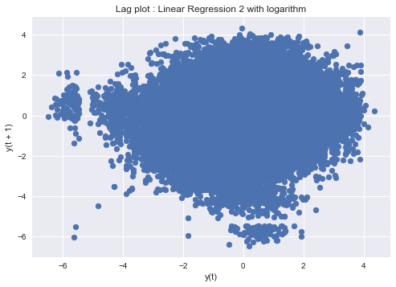

```python
plt.title('Lag plot : Linear Regression 2 with logarithm')
lag_plot(regr2_log.resid)
plt.savefig('figure/Figure - Lag plot : Linear Regression 2 with logarithm.png', dpi=300)
```

```python
durbin_watson(regr2_log.resid)
```

[output not shown]

The lag plot does not show a structured form. The residues seem independent. This is confirmed by the Durbin-Watson test whose statistic is close to 2.

#### Evaluation of the hypothesis of normality of residues

```python
plot_qq_plot(regr2_log,'Linear Regression 2 with logarithm')
```

[output not shown]

```python
test_shapiro(regr2_log)
```

```
Statistics=0.992, p=0.000
Sample does not look Gaussian (reject H0)
```

In comparison with the non-logarithmic case, the points are better aligned with the first bisector: the distribution follows approximately a Gaussian normalized distribution law. The hypothesis of normality of the residues seems verified. However, the Shapiro-Wilk test tells us the opposite and rejects the hypothesis H0, hypothesis of normality of residues: this may be due to influential outliers / points or because the number of data studied is very large.

#### Evaluation of the homogeneity hypothesis of residues

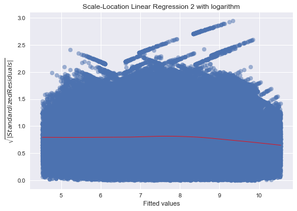

```python
plot_scale_location(regr2_log,'Linear Regression 2 with logarithm')
```

```python
test_breuschpagan(regr2_log)
```

```
Statistics=14900.772, p=0.000
Residue homogeneity assumption is rejected.
```

In comparison with the non-logarithmic case, the variance of the residues seems constant. The hypothesis of homogeneity of residues seems to be verified. However, the Breusch-Pagan test tells us the opposite and rejects the hypothesis H0, hypothesis of homogeneity of the residues: this can be due to influential outliers / points or because the number of data studied is very large.

#### Results analysis

```python
print(regr2_log.summary())
```

```
                            OLS Regression Results
==============================================================================
Dep. Variable:           income_child   R-squared:                       0.707
Model:                            OLS   Adj. R-squared:                  0.707
Method:                 Least Squares   F-statistic:                 9.265e+05
Date:                Mon, 28 Oct 2019   Prob (F-statistic):               0.00
Time:                        12:54:58   Log-Likelihood:            -1.3006e+06
No. Observations:             1150000   AIC:                         2.601e+06
Df Residuals:                 1149996   BIC:                         2.601e+06
Df Model:                           3
Covariance Type:            nonrobust
===============================================================================
                  coef    std err          t      P>|t|      [0.025      0.975]
-------------------------------------------------------------------------------
Intercept       0.4671      0.007     66.121      0.000       0.453       0.481
gdpppp          0.8578      0.001   1466.759      0.000       0.857       0.859
indice_gini    -0.0187   8.91e-05   -209.900      0.000      -0.019      -0.019
c_k_parent      0.0108   2.42e-05    446.837      0.000       0.011       0.011
==============================================================================
Omnibus:                    35788.403   Durbin-Watson:                   1.501
Prob(Omnibus):                  0.000   Jarque-Bera (JB):            88571.098
Skew:                          -0.128   Prob(JB):                         0.00
Kurtosis:                       4.335   Cond. No.                         691.
==============================================================================

Warnings:
[1] Standard Errors assume that the covariance matrix of the errors is correctly specified.
```

#### Checking collinearity of variables

```python
test_colinearite(regr2_log)
```

```
[1.0883557856292718, 1.0883555318032077, 1.0000003248677485]
```

The VIF coefficients of our variables are < 10: there is no collinearity problem.

#### Distance from Cook: Influent Outliers

```python
pourcentage_outliers_influents(final_data_sampled_log, regr2_log)
```

```
5.48 % of individuals are influential outliers
```

These points influence the regression. However, they are preserved because they are supposed to represent real individuals.

#### Results Analysis

Prob (F-statistic) < 5%: The model is significant.

P-values: index_gini, gdpppp, c_k_parent: < 5%: The coefficients are significant with a 95% confidence interval.

By observing the regression coefficient associated with the Gini index, can we say that living in a more unequal country favors more people than it does not?

The child's income has the following expression:

ln (child_income) = const - 0.0188 x gini + 0.8575 x ln (gdpppp) + 0.0108 x c_k_parent

Middle income and constant parent class:

ln (income_child) = alpha - 0.0188 x gini where income_child = $ e ^ {alpha} $ / $ e ^ {0.0188gini} $

For a child from a country 1 more unequal than a country 2 (gini1> gini2), a country with the same average income, and having parents belonging to the same class:

income_enfant1 < income_child2 **It can not therefore be said that living in a more unequal country favors more people than it disadvantages. It's the contrary.** But how much? Increasing the Gini index by n amounts to dividing the child's income by $ e ^ {0.0188n} $.

```python
print('In 2008, the Gini index of South Africa was', gini_2008[gini_2008['country_name']=='South Africa']['indice_gini'].sum())
print('In 2008, the Gini index of France was', gini_2008[gini_2008['country_name']=='France']['indice_gini'].sum())
```

```
In 2008, the Gini index of South Africa was 63.0
In 2008, the Gini index of France was 33.0
```

#### Decomposition of total variance explained

```python
res_regr2_log = sm.stats.anova_lm(regr2_log, typ=2)
res_regr2_log
```

|  | sum_sq | df | F | PR(>F) |
| --- | --- | --- | --- | --- |
| gdpppp | 1.209462e+06 | 1.0 | 2.151381e+06 | 0.0 |
| indice_gini | 2.476844e+04 | 1.0 | 4.405791e+04 | 0.0 |
| c_k_parent | 1.122467e+05 | 1.0 | 1.996635e+05 | 0.0 |
| Residual | 6.465038e+05 | 1149996.0 | NaN | NaN |

```python
regr2_log_sct = res_regr2_log.values[:,0].sum()
regr2_log_sce = res_regr2_log.values[0,0]+res_regr2_log.values[1,0]+res_regr2_log.values[2,0]
regr2_log_scr = res_regr2_log.values[3,0]
regr2_log_sce_gdpppp = sm.stats.anova_lm(regr2_log, typ=2).values[0,0]/regr2_log_sct
regr2_log_sce_indice_gini = sm.stats.anova_lm(regr2_log, typ=2).values[1,0]/regr2_log_sct
regr2_log_sce_c_k_parent = sm.stats.anova_lm(regr2_log, typ=2).values[2,0]/regr2_log_sct
regr2_log_r2 = regr2_log_sce/regr2_log_sct

print("        SCT = ", round(regr2_log_sct))
print("        SCE = ", round(regr2_log_sce))
print("        SCR = ", round(regr2_log_scr))
print("Variance explained by the country's average income (gdpppp ) =",round(100*regr2_log_sce_gdpppp,2),'%')
print("                 Variance explained by the gini index = ",round(100*regr2_log_sce_indice_gini,2),'%')
print("            Variance explained by parents' class = ",round(100*regr2_log_sce_c_k_parent,2),'%')
print("              Variance explained by the R2-squared model = ", round(100*regr2_log_r2),"%")
print("                      Variance unexplained by the model = ", round(100*regr2_log_scr/regr2_log_sct),"%")
print("Conclusion : The model ln(gdpppp) + indice_gini + c_k_parent + explain", round(100*regr2_log_r2),"% of the total variance of ln(income_enfant).")
```

```
        SCT =  1992981.0
        SCE =  1346477.0
        SCR =  646504.0
Variance explained by the country's average income (gdpppp ) = 60.69 %
                 Variance explained by the gini index =  1.24 %
            Variance explained by parents' class =  5.63 %
              Variance explained by the R2-squared model =  68.0 %
                      Variance unexplained by the model =  32.0 %
Conclusion : The model ln(gdpppp) + indice_gini + c_k_parent + explain 68.0 % of the total variance of ln(income_enfant).
```

In this 4th part, we used 3 models.

ANOVA explains 50% of the variation in the child's income.

The linear regression 1 with the average income and the Gini index of the country explains to 62% the variation of the income of the child.

The linear regression 2, by adding the income class of the parents, to 68% the variation of the incomes of the child.

This last model is the most powerful and can be used to predict the child's income, knowing the Gini index and the average income of the country, as well as the income class of his parents.